# International Dimensions of Business Final Project

The dataset we are analyzing is coming from a [Kaggle posting](https://www.kaggle.com/datasets/gregorut/videogamesales) where they got their information from [VGCharts](https://www.vgchartz.com/) as the post acknowledged. VGChartz is a video game industry research firm that hosts a game database system that features current and legacy video game sales data among providing other content such as news, sales (discounts), reviews, articles, and a social network supported with a community forum.

### About the Dataset

Fields include

- Rank - Ranking of overall sales
- Name - The games name
- Platform - Platform of the games release (i.e. PC,PS4, etc.)
- Year - Year of the game's release
- Genre - Genre of the game
- Publisher - Publisher of the game
- NA_Sales - Sales in North America (in millions)
- EU_Sales - Sales in Europe (in millions)
- JP_Sales - Sales in Japan (in millions)
- Other_Sales - Sales in the rest of the world (in millions)
- Global_Sales - Total worldwide sales.

The script to scrape the data is available [here](https://github.com/GregorUT/vgchartzScrape). It is based on BeautifulSoup using Python. There are 16,598 records. 2 records were dropped due to incomplete information.

### Libraries

```python
import pandas as pd
import matplotlib.pyplot as plt
#importing libraries
```

### Loading data

```python
vgsales = pd.read_csv('vgsales.csv') #loading data
```

### Summary Information

```python
vgsales.head() #displays top 5 rows
```

|  | Rank | Name | Platform | Year | Genre | Publisher | NA_Sales | EU_Sales | JP_Sales | Other_Sales | Global_Sales |
| --- | --- | --- | --- | --- | --- | --- | --- | --- | --- | --- | --- |
| 0 | 1 | Wii Sports | Wii | 2006.0 | Sports | Nintendo | 41.49 | 29.02 | 3.77 | 8.46 | 82.74 |
| 1 | 2 | Super Mario Bros. | NES | 1985.0 | Platform | Nintendo | 29.08 | 3.58 | 6.81 | 0.77 | 40.24 |
| 2 | 3 | Mario Kart Wii | Wii | 2008.0 | Racing | Nintendo | 15.85 | 12.88 | 3.79 | 3.31 | 35.82 |
| 3 | 4 | Wii Sports Resort | Wii | 2009.0 | Sports | Nintendo | 15.75 | 11.01 | 3.28 | 2.96 | 33.00 |
| 4 | 5 | Pokemon Red/Pokemon Blue | GB | 1996.0 | Role-Playing | Nintendo | 11.27 | 8.89 | 10.22 | 1.00 | 31.37 |

```python
unique_names = vgsales.drop_duplicates(subset=['Name']).reset_index(drop=True)

unique_names
```

|  | Rank | Name | Platform | Year | Genre | Publisher | NA_Sales | EU_Sales | JP_Sales | Other_Sales | Global_Sales |
| --- | --- | --- | --- | --- | --- | --- | --- | --- | --- | --- | --- |
| 0 | 1 | Wii Sports | Wii | 2006.0 | Sports | Nintendo | 41.49 | 29.02 | 3.77 | 8.46 | 82.74 |
| 1 | 2 | Super Mario Bros. | NES | 1985.0 | Platform | Nintendo | 29.08 | 3.58 | 6.81 | 0.77 | 40.24 |
| 2 | 3 | Mario Kart Wii | Wii | 2008.0 | Racing | Nintendo | 15.85 | 12.88 | 3.79 | 3.31 | 35.82 |
| 3 | 4 | Wii Sports Resort | Wii | 2009.0 | Sports | Nintendo | 15.75 | 11.01 | 3.28 | 2.96 | 33.00 |
| 4 | 5 | Pokemon Red/Pokemon Blue | GB | 1996.0 | Role-Playing | Nintendo | 11.27 | 8.89 | 10.22 | 1.00 | 31.37 |
| ... | ... | ... | ... | ... | ... | ... | ... | ... | ... | ... | ... |
| 11488 | 16592 | Chou Ezaru wa Akai Hana: Koi wa Tsuki ni Shiru... | PSV | 2016.0 | Action | dramatic create | 0.00 | 0.00 | 0.01 | 0.00 | 0.01 |
| 11489 | 16593 | Eiyuu Densetsu: Sora no Kiseki Material Collec... | PSP | 2007.0 | Role-Playing | Falcom Corporation | 0.00 | 0.00 | 0.01 | 0.00 | 0.01 |
| 11490 | 16595 | Plushees | DS | 2008.0 | Simulation | Destineer | 0.01 | 0.00 | 0.00 | 0.00 | 0.01 |
| 11491 | 16596 | Woody Woodpecker in Crazy Castle 5 | GBA | 2002.0 | Platform | Kemco | 0.01 | 0.00 | 0.00 | 0.00 | 0.01 |
| 11492 | 16599 | Know How 2 | DS | 2010.0 | Puzzle | 7G//AMES | 0.00 | 0.01 | 0.00 | 0.00 | 0.01 |

11493 rows × 11 columns

```python
year_counts_unique = unique_names['Year'].value_counts()

year_counts_unique_df = pd.DataFrame(year_counts_unique).sort_index(ascending=True)
year_counts_unique_df.index = year_counts_unique_df.index.astype(int)
year_counts_unique_df.head()   #take out if you want to see full table

#find the amount of year occurences without replicated game title names. For instance all of the times Call of Duty Black ops happens for every platform, like for xbox and play station. instead it will just show one.
#then this is counted
```

|  | Year |
| --- | --- |
| 1980 | 8 |
| 1981 | 43 |
| 1982 | 33 |
| 1983 | 16 |
| 1984 | 13 |

```python
vgsales.describe() #gives some summary statistics about the data
```

|  | Rank | Year | NA_Sales | EU_Sales | JP_Sales | Other_Sales | Global_Sales |
| --- | --- | --- | --- | --- | --- | --- | --- |
| count | 16598.000000 | 16327.000000 | 16598.000000 | 16598.000000 | 16598.000000 | 16598.000000 | 16598.000000 |
| mean | 8300.605254 | 2006.406443 | 0.264667 | 0.146652 | 0.077782 | 0.048063 | 0.537441 |
| std | 4791.853933 | 5.828981 | 0.816683 | 0.505351 | 0.309291 | 0.188588 | 1.555028 |
| min | 1.000000 | 1980.000000 | 0.000000 | 0.000000 | 0.000000 | 0.000000 | 0.010000 |
| 25% | 4151.250000 | 2003.000000 | 0.000000 | 0.000000 | 0.000000 | 0.000000 | 0.060000 |
| 50% | 8300.500000 | 2007.000000 | 0.080000 | 0.020000 | 0.000000 | 0.010000 | 0.170000 |
| 75% | 12449.750000 | 2010.000000 | 0.240000 | 0.110000 | 0.040000 | 0.040000 | 0.470000 |
| max | 16600.000000 | 2020.000000 | 41.490000 | 29.020000 | 10.220000 | 10.570000 | 82.740000 |

```python
vgsales.dtypes

#shows the data types of the columns
```

```
Rank              int64
Name             object
Platform         object
Year            float64
Genre            object
Publisher        object
NA_Sales        float64
EU_Sales        float64
JP_Sales        float64
Other_Sales     float64
Global_Sales    float64
dtype: object
```

```python
countingtitlenames = vgsales['Name'].notnull() #counts the name column for non null rows


countingtitlenames = countingtitlenames.sum() #adds them

countingtitlenames # prints the non null values in name column
```

```
16598
```

```python
num_of_index = len(vgsales)

num_of_index #prints the amount of indexs in the dataframe
```

```
16598
```

```python
sum_of_NA = round(vgsales['NA_Sales'].sum())

sum_of_JP = round(vgsales['JP_Sales'].sum())

sum_of_EU = round(vgsales['EU_Sales'].sum())

sum_of_other = round(vgsales['Other_Sales'].sum())

sum_of_global = round(vgsales['Global_Sales'].sum())

print('sum of sales NA:' , sum_of_NA )
print('sum of sales JP:' , sum_of_JP )
print('sum of sales EU:' , sum_of_EU )
print('sum of sales Other:' , sum_of_other)
print('sum of sales Global:' , sum_of_global )


#prints the sum of sales in each region
```

```
sum of sales NA: 4393
sum of sales JP: 1291
sum of sales EU: 2434
sum of sales Other: 798
sum of sales Global: 8920
```

```python
year_counts = vgsales['Year'].value_counts()

year_counts.head() # counts the amount of years
```

```
2009.0    1431
2008.0    1428
2010.0    1259
2007.0    1202
2011.0    1139
Name: Year, dtype: int64
```

```python
year_counts_df = pd.DataFrame(year_counts).sort_index(ascending=True)
year_counts_df.index = year_counts_df.index.astype(int)
year_counts_df.head() #take out head if you want to see full table

#made the counts of years in a dataframe with years as an index
```

|  | Year |
| --- | --- |
| 1980 | 9 |
| 1981 | 46 |
| 1982 | 36 |
| 1983 | 17 |
| 1984 | 14 |

```python
year_counts_df['Year'].sum()

#checks the to see if years rows matches index. IT DOES NOT. 16598 is the amount of indexs. SO, there are missing years.
```

```
16327
```

```python
countingyears = vgsales['Year'].notnull() #counts the name column for non null rows


countingyears = countingyears.sum() #adds them

countingyears

#this confirms the theory that years are missing.
```

```
16327
```

### Top Games by Region

```python
groupedNA_df = vgsales.groupby('Name')['NA_Sales'].sum().reset_index()
groupedNA_df = groupedNA_df.sort_values('NA_Sales', ascending= False).head()
groupedNA_df

#prints a table of the most sold games in NA
```

|  | Name | NA_Sales |
| --- | --- | --- |
| 11007 | Wii Sports | 41.49 |
| 9327 | Super Mario Bros. | 32.48 |
| 2590 | Duck Hunt | 26.93 |
| 9715 | Tetris | 26.17 |
| 3712 | Grand Theft Auto V | 23.46 |

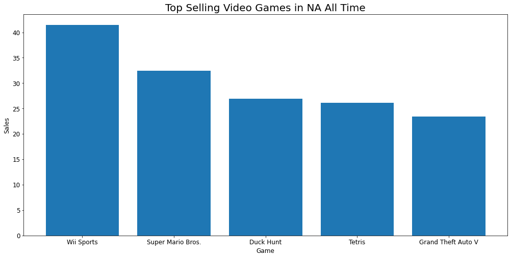

```python
plt.figure(figsize=(17, 8))
plt.bar(groupedNA_df['Name'], groupedNA_df['NA_Sales'])

plt.xlabel('Game', fontsize=12)
plt.ylabel('Sales', fontsize=12)
plt.title('Top Selling Video Games in NA All Time',fontsize=20)

plt.xticks(fontsize=12)
plt.yticks(fontsize=12)


plt.show()
plt.close()
#graph of the table
```

```python
groupedJP_df = vgsales.groupby('Name')['JP_Sales'].sum().reset_index()
groupedJP_df = groupedJP_df.sort_values('JP_Sales', ascending= False).head()
groupedJP_df

#prints a table of the most sold games in JP
```

|  | Name | JP_Sales |
| --- | --- | --- |
| 7346 | Pokemon Red/Pokemon Blue | 10.22 |
| 7333 | Pokemon Gold/Pokemon Silver | 7.20 |
| 9327 | Super Mario Bros. | 6.96 |
| 6723 | New Super Mario Bros. | 6.50 |
| 7331 | Pokemon Diamond/Pokemon Pearl | 6.04 |

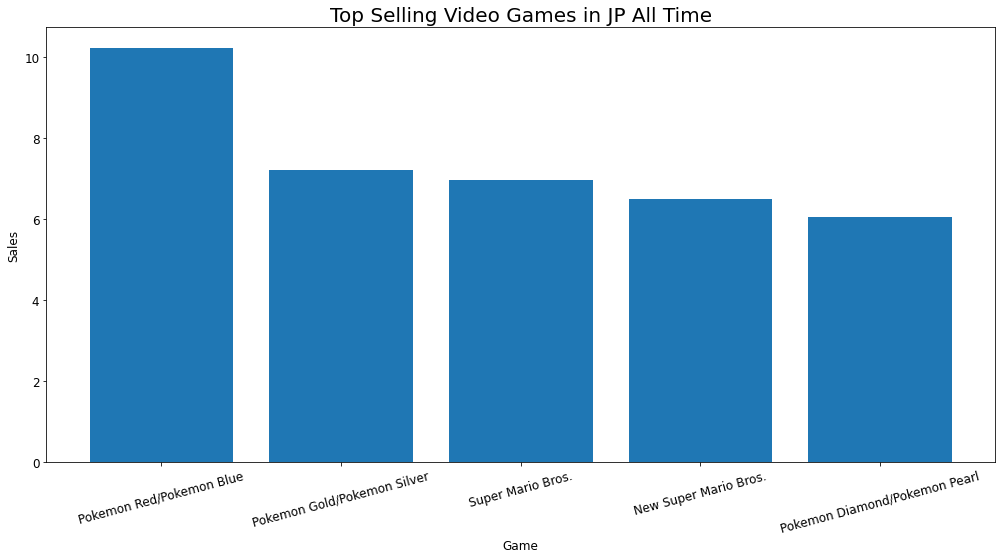

```python
plt.figure(figsize=(17, 8))
plt.bar(groupedJP_df['Name'], groupedJP_df['JP_Sales'])

plt.xlabel('Game',fontsize=12)
plt.ylabel('Sales',fontsize=12)
plt.title('Top Selling Video Games in JP All Time',fontsize=20)


plt.xticks(fontsize=12, rotation = 15)
plt.yticks(fontsize=12)


plt.show()
plt.close()

#graph of the table
```

```python
groupedEU_df = vgsales.groupby('Name')['EU_Sales'].sum().reset_index()
groupedEU_df = groupedEU_df.sort_values('EU_Sales', ascending= False).head()
groupedEU_df

#prints a table of the most sold games in EU
```

|  | Name | EU_Sales |
| --- | --- | --- |
| 11007 | Wii Sports | 29.02 |
| 3712 | Grand Theft Auto V | 23.04 |
| 5573 | Mario Kart Wii | 12.88 |
| 2924 | FIFA 15 | 12.40 |
| 1228 | Call of Duty: Modern Warfare 3 | 11.29 |

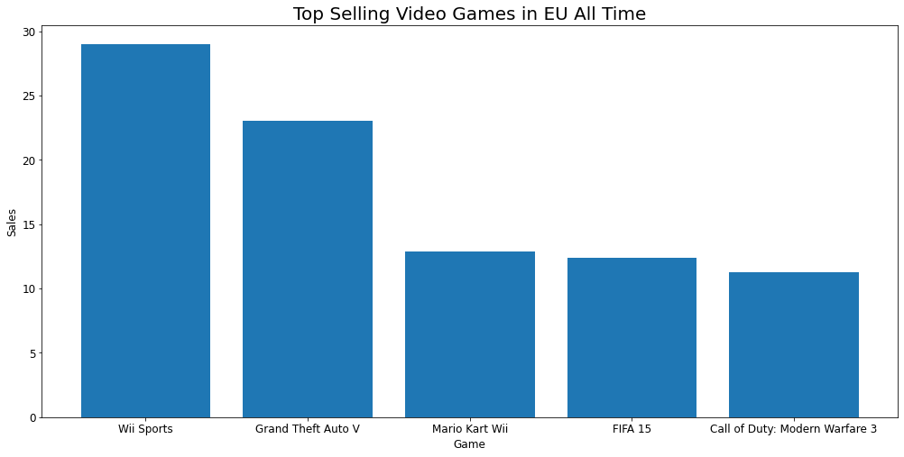

```python
plt.figure(figsize=(17, 8))
plt.bar(groupedEU_df['Name'], groupedEU_df['EU_Sales'])

plt.xlabel('Game',fontsize=12)
plt.ylabel('Sales',fontsize=12)
plt.title('Top Selling Video Games in EU All Time',fontsize=20)

plt.xticks(fontsize=12)
plt.yticks(fontsize=12)


plt.show()
plt.close()
#graph of the table
```

```python
groupedOther_df = vgsales.groupby('Name')['Other_Sales'].sum().reset_index()
groupedOther_df = groupedOther_df.sort_values('Other_Sales', ascending= False).head()
groupedOther_df

#prints a table of the most sold games in Other
```

|  | Name | Other_Sales |
| --- | --- | --- |
| 3716 | Grand Theft Auto: San Andreas | 10.72 |
| 11007 | Wii Sports | 8.46 |
| 3712 | Grand Theft Auto V | 8.03 |
| 3694 | Gran Turismo 4 | 7.53 |
| 1224 | Call of Duty: Black Ops II | 3.88 |

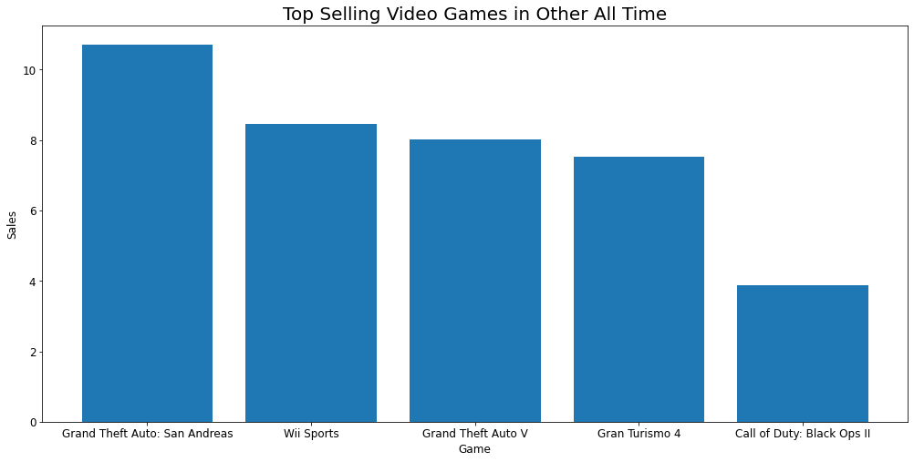

```python
plt.figure(figsize=(17, 8))
plt.bar(groupedOther_df['Name'], groupedOther_df['Other_Sales'])


plt.xlabel('Game',fontsize=12)
plt.ylabel('Sales',fontsize=12)
plt.title('Top Selling Video Games in Other All Time',fontsize=20)



plt.xticks(fontsize=12)
plt.yticks(fontsize=12)


plt.show()
plt.close()

#graph of the table
```

```python
groupedGlobal_df = vgsales.groupby('Name')['Global_Sales'].sum().reset_index()
groupedGlobal_df = groupedGlobal_df.sort_values('Global_Sales', ascending= False).head()
groupedGlobal_df

#prints a table of the most sold games in Global
```

|  | Name | Global_Sales |
| --- | --- | --- |
| 11007 | Wii Sports | 82.74 |
| 3712 | Grand Theft Auto V | 55.92 |
| 9327 | Super Mario Bros. | 45.31 |
| 9715 | Tetris | 35.84 |
| 5573 | Mario Kart Wii | 35.82 |

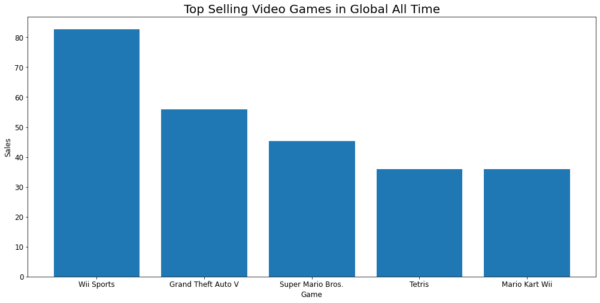

```python
plt.figure(figsize=(17, 8))
plt.bar(groupedGlobal_df['Name'], groupedGlobal_df['Global_Sales'])


plt.xlabel('Game',fontsize=12)
plt.ylabel('Sales',fontsize=12)
plt.title('Top Selling Video Games in Global All Time',fontsize=20)


plt.xticks(fontsize=12)
plt.yticks(fontsize=12)


plt.show()
plt.close()

#graph of the table
```

### How Many Games Were Made Over Time?

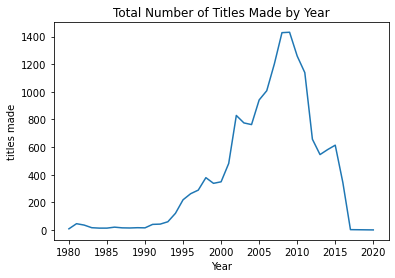

```python
plt.plot(year_counts_df.index, year_counts_df['Year'])
plt.xlabel('Year')
plt.ylabel('titles made')
plt.title('Total Number of Titles Made by Year')
plt.show()

#graph of games made over time
```

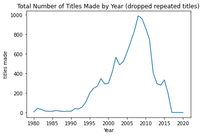

```python
plt.plot(year_counts_unique_df.index, year_counts_unique_df['Year'])
plt.xlabel('Year')
plt.ylabel('titles made')
plt.title('Total Number of Titles Made by Year (dropped repeated titles)')
plt.show()
```

### Proportion of Game Sales by Region

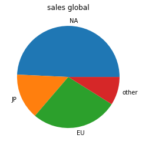

```python
labels = ['NA', 'JP', 'EU', 'other']
sizes = [4392, 1291, 2434, 798]


fig, ax = plt.subplots()
ax.pie(sizes, labels=labels)


ax.set_title('sales global')

fig.set_facecolor('white')

plt.show()

#takes the sales and regions and makes a pie graph with white facecolor
```

```python
platformunique = vgsales['Platform'].nunique()

platformunique #counts unique number of platforms
```

```
31
```

```python
genreunique = vgsales['Genre'].nunique()

genreunique  #counts unique number of genres
```

```
12
```

```python
publishersunique = vgsales['Publisher'].nunique()

publishersunique #counts unique number of publishers
```

```
578
```

## Region Sales by Platorm

The number of games sold for a platform per region.

### Japanese Sales by Platform

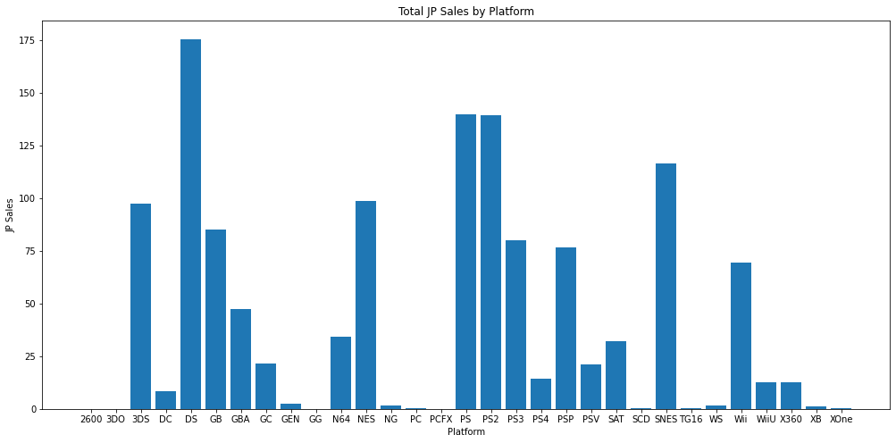

```python
platform_sales_jap = vgsales.groupby('Platform')['JP_Sales'].sum().reset_index()

plt.figure(figsize=(17, 8))
plt.bar(platform_sales_jap['Platform'], platform_sales_jap['JP_Sales'])

plt.xlabel('Platform')
plt.ylabel('JP Sales')
plt.title('Total JP Sales by Platform')

#groups platform and sales and then makes a bar graph with platform on the x
```

### North American Sales by Platform

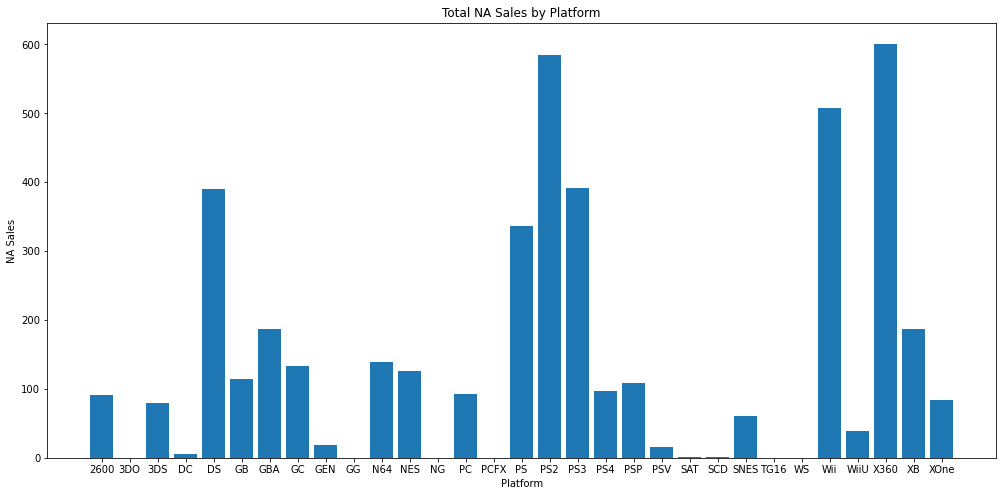

```python
platform_sales_NA = vgsales.groupby('Platform')['NA_Sales'].sum().reset_index()

plt.figure(figsize=(17, 8))
plt.bar(platform_sales_NA['Platform'], platform_sales_NA['NA_Sales'])

plt.xlabel('Platform')
plt.ylabel('NA Sales')
plt.title('Total NA Sales by Platform')

#groups platform and sales and then makes a bar graph with platform on the x
```

### European Sales by Platform

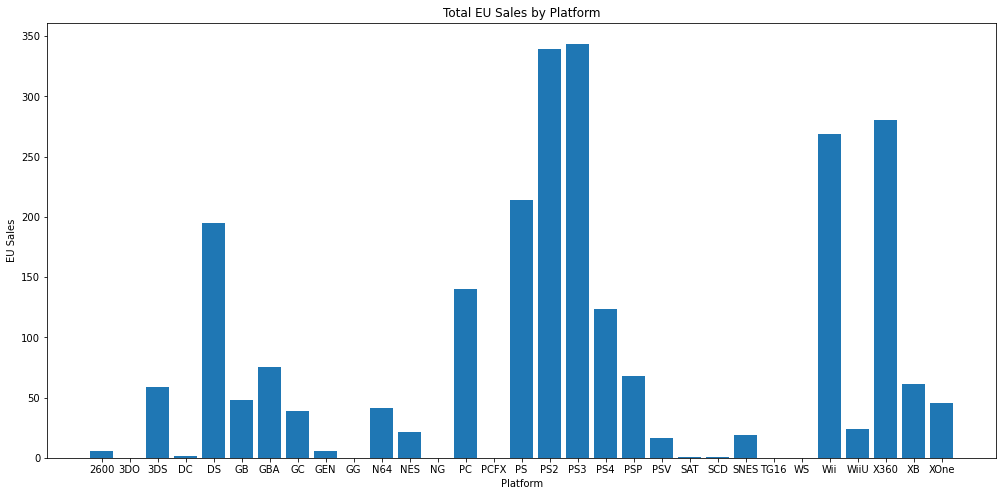

```python
platform_sales_EU = vgsales.groupby('Platform')['EU_Sales'].sum().reset_index()

plt.figure(figsize=(17, 8))
plt.bar(platform_sales_EU['Platform'], platform_sales_EU['EU_Sales'])

plt.xlabel('Platform')
plt.ylabel('EU Sales')
plt.title('Total EU Sales by Platform')
#groups platform and sales and then makes a bar graph with platform on the x
```

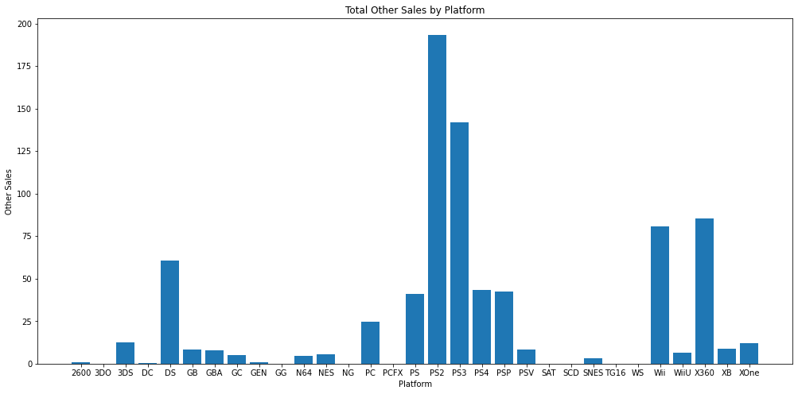

```python
platform_sales_Other = vgsales.groupby('Platform')['Other_Sales'].sum().reset_index()

plt.figure(figsize=(17, 8))
plt.bar(platform_sales_Other['Platform'], platform_sales_Other['Other_Sales'])

plt.xlabel('Platform')
plt.ylabel('Other Sales')
plt.title('Total Other Sales by Platform')
#groups platform and sales and then makes a bar graph with platform on the x
```

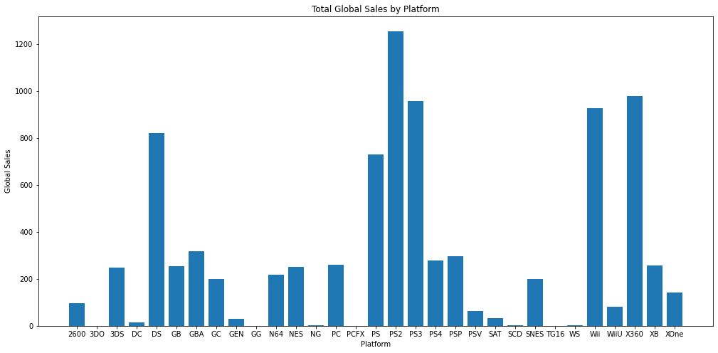

```python
platform_sales_Global = vgsales.groupby('Platform')['Global_Sales'].sum().reset_index()

plt.figure(figsize=(17, 8))
plt.bar(platform_sales_Global['Platform'], platform_sales_Global['Global_Sales'])

plt.xlabel('Platform')
plt.ylabel('Global Sales')
plt.title('Total Global Sales by Platform')
#groups platform and sales and then makes a bar graph with platform on the x
```

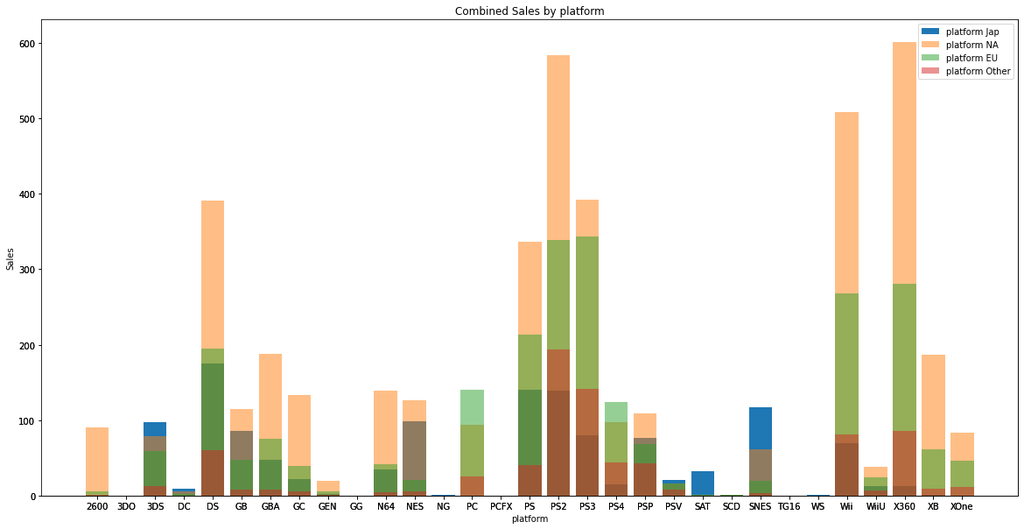

```python
fig, axs = plt.subplots(figsize=(20, 10))


axs.bar(platform_sales_jap['Platform'], platform_sales_jap['JP_Sales'])
axs.bar(platform_sales_NA['Platform'], platform_sales_NA['NA_Sales'])
axs.bar(platform_sales_EU['Platform'], platform_sales_EU['EU_Sales'])
axs.bar(platform_sales_Other['Platform'], platform_sales_Other['Other_Sales'])

axs_combined = fig.add_subplot()


axs_combined.bar(platform_sales_jap['Platform'], platform_sales_jap['JP_Sales'], align='center', label='platform Jap',alpha=1)
axs_combined.bar(platform_sales_NA['Platform'], platform_sales_NA['NA_Sales'], align='center', label='platform NA',alpha=0.5)
axs_combined.bar(platform_sales_EU['Platform'], platform_sales_EU['EU_Sales'], align='center', label='platform EU',alpha=0.5)
axs_combined.bar(platform_sales_Other['Platform'], platform_sales_Other['Other_Sales'], align='center', label='platform Other',alpha=0.5)

axs_combined.set_xlabel('platform')
axs_combined.set_ylabel('Sales')


axs_combined.set_title('Combined Sales by platform')
axs_combined.legend()


plt.show()

#this combines all of the past graphs and stacks them so you can see the differences between the regions
```

## Sales By Year

The total number of video games sold per region.

### Number of video games sold per year in Japan

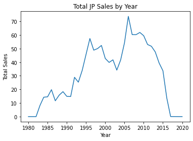

```python
sales_by_year_jap = vgsales.groupby('Year')['JP_Sales'].sum().reset_index()


plt.plot(sales_by_year_jap['Year'], sales_by_year_jap['JP_Sales'])
plt.xlabel('Year')
plt.ylabel('Total Sales')
plt.title('Total JP Sales by Year')
plt.show()


# groups year and sales and prints a time series graph over time
```

### Number of video games sold per year in North America

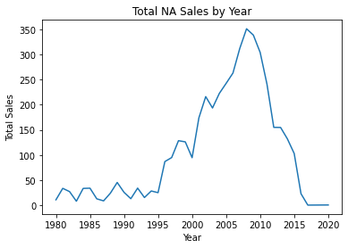

```python
sales_by_year_NA = vgsales.groupby('Year')['NA_Sales'].sum().reset_index()


plt.plot(sales_by_year_NA['Year'], sales_by_year_NA['NA_Sales'])
plt.xlabel('Year')
plt.ylabel('Total Sales')
plt.title('Total NA Sales by Year')
plt.show()

# groups year and sales and prints a time series graph over time
```

### Number of video games sold per year in the EU

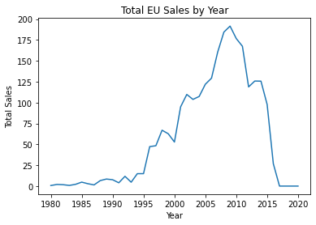

```python
sales_by_year_EU = vgsales.groupby('Year')['EU_Sales'].sum().reset_index()


plt.plot(sales_by_year_EU['Year'], sales_by_year_EU['EU_Sales'])
plt.xlabel('Year')
plt.ylabel('Total Sales')
plt.title('Total EU Sales by Year')
plt.show()

# groups year and sales and prints a time series graph over time
```

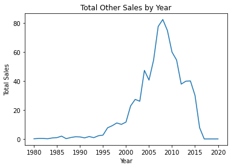

```python
sales_by_year_Other = vgsales.groupby('Year')['Other_Sales'].sum().reset_index()


plt.plot(sales_by_year_Other['Year'], sales_by_year_Other['Other_Sales'])
plt.xlabel('Year')
plt.ylabel('Total Sales')
plt.title('Total Other Sales by Year')
plt.show()

# groups year and sales and prints a time series graph over time
```

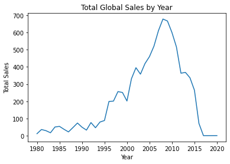

```python
sales_by_year_Global = vgsales.groupby('Year')['Global_Sales'].sum().reset_index()


plt.plot(sales_by_year_Global['Year'], sales_by_year_Global['Global_Sales'])
plt.xlabel('Year')
plt.ylabel('Total Sales')
plt.title('Total Global Sales by Year')
plt.show()


# groups year and sales and prints a time series graph over time
```

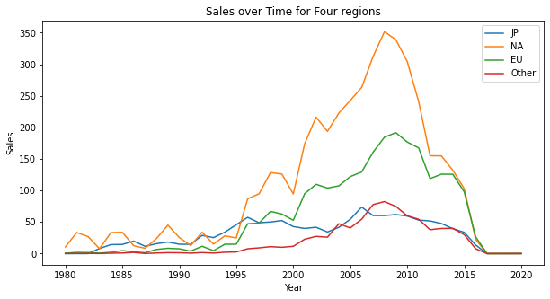

```python
df1s = sales_by_year_jap.set_index('Year')
df2s = sales_by_year_NA.set_index('Year')
df3s = sales_by_year_EU.set_index('Year')
df4s = sales_by_year_Other.set_index('Year')

fig, ax = plt.subplots(figsize=(10, 5))


ax.plot(df1s.index, df1s['JP_Sales'], label='JP')
ax.plot(df2s.index, df2s['NA_Sales'], label='NA')
ax.plot(df3s.index, df3s['EU_Sales'], label='EU')
ax.plot(df4s.index, df4s['Other_Sales'], label='Other')

ax.set_title('Sales over Time for Four regions')
ax.set_xlabel('Year')
ax.set_ylabel('Sales')


ax.legend()


plt.show()

#this is the a combination of the last time series graphs to see the differences.
```

## Genre of Video Games Sold by Region

A good indicator of popular genres in a particular region.

### Genre of Video Games Sold in Japan

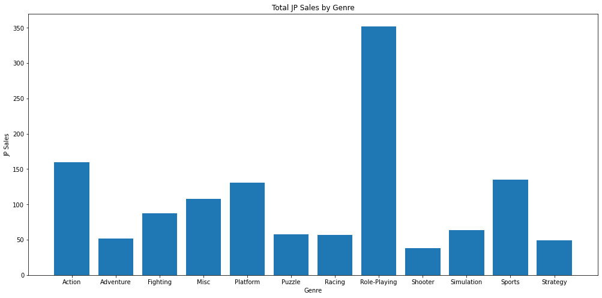

```python
genre_sales_JP = vgsales.groupby('Genre')['JP_Sales'].sum().reset_index()

plt.figure(figsize=(17, 8))
plt.bar(genre_sales_JP['Genre'], genre_sales_JP['JP_Sales'])

plt.xlabel('Genre')
plt.ylabel('JP Sales')
plt.title('Total JP Sales by Genre')


#this shows the genre sales in the region
```

### Genre of Video Games Sold in North America

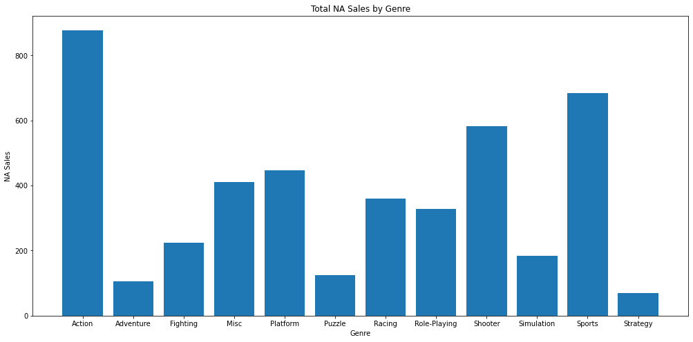

```python
genre_sales_NA = vgsales.groupby('Genre')['NA_Sales'].sum().reset_index()

plt.figure(figsize=(17, 8))
plt.bar(genre_sales_NA['Genre'], genre_sales_NA['NA_Sales'])

plt.xlabel('Genre')
plt.ylabel('NA Sales')
plt.title('Total NA Sales by Genre')

#this shows the genre sales in the region
```

#### Genre of Video Games Sold in the EU

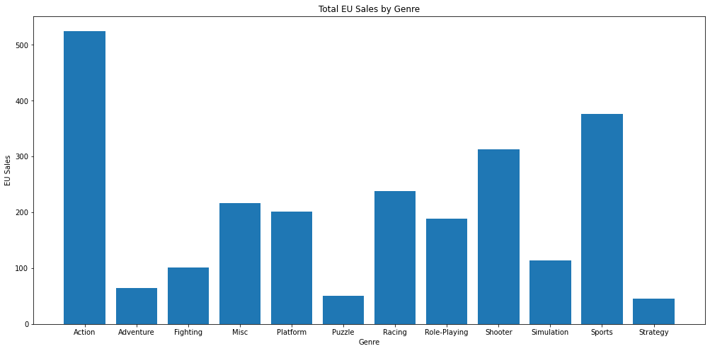

```python
genre_sales_EU = vgsales.groupby('Genre')['EU_Sales'].sum().reset_index()

plt.figure(figsize=(17, 8))
plt.bar(genre_sales_EU['Genre'], genre_sales_EU['EU_Sales'])

plt.xlabel('Genre')
plt.ylabel('EU Sales')
plt.title('Total EU Sales by Genre')

#this shows the genre sales in the region
```

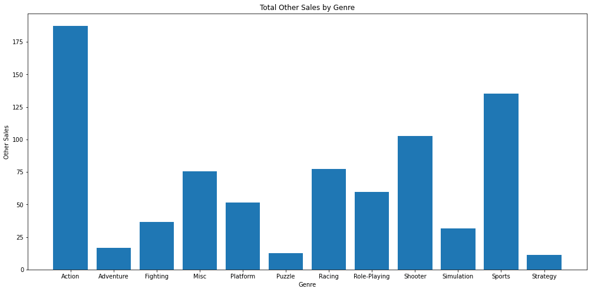

```python
genre_sales_Other = vgsales.groupby('Genre')['Other_Sales'].sum().reset_index()

plt.figure(figsize=(17, 8))
plt.bar(genre_sales_Other['Genre'], genre_sales_Other['Other_Sales'])

plt.xlabel('Genre')
plt.ylabel('Other Sales')
plt.title('Total Other Sales by Genre')

#this shows the genre sales in the other regions
```

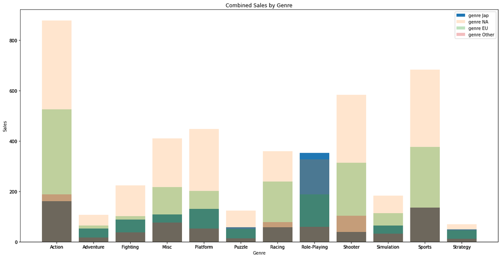

```python
fig, axs = plt.subplots(figsize=(20, 10))


axs.bar(genre_sales_JP['Genre'], genre_sales_JP['JP_Sales'])
axs.bar(genre_sales_NA['Genre'], genre_sales_NA['NA_Sales'])
axs.bar(genre_sales_EU['Genre'], genre_sales_EU['EU_Sales'])
axs.bar(genre_sales_Other['Genre'], genre_sales_Other['Other_Sales'])

axs_combined = fig.add_subplot()


axs_combined.bar(genre_sales_JP['Genre'], genre_sales_JP['JP_Sales'], align='center', label='genre Jap',alpha=1)
axs_combined.bar(genre_sales_NA['Genre'], genre_sales_NA['NA_Sales'], align='center', label='genre NA',alpha=0.2)
axs_combined.bar(genre_sales_EU['Genre'], genre_sales_EU['EU_Sales'], align='center', label='genre EU',alpha=0.3)
axs_combined.bar(genre_sales_Other['Genre'], genre_sales_Other['Other_Sales'], align='center', label='genre Other',alpha=0.3)


axs_combined.set_xlabel('Genre')
axs_combined.set_ylabel('Sales')


axs_combined.set_title('Combined Sales by Genre')
axs_combined.legend()


plt.show()



# this is a combination of the last graphs overlayed so you can see the differences.
```

```python
publisher_sales_jap = vgsales.groupby('Publisher')['JP_Sales'].sum().reset_index()

publisher_sales_jap_sorted = publisher_sales_jap.sort_values('JP_Sales', ascending=False)
```

```python
top5pubsjap = publisher_sales_jap_sorted.head(5)
top5pubsjap
```

|  | Publisher | JP_Sales |
| --- | --- | --- |
| 359 | Nintendo | 455.42 |
| 347 | Namco Bandai Games | 127.07 |
| 275 | Konami Digital Entertainment | 91.30 |
| 456 | Sony Computer Entertainment | 74.10 |
| 85 | Capcom | 68.08 |

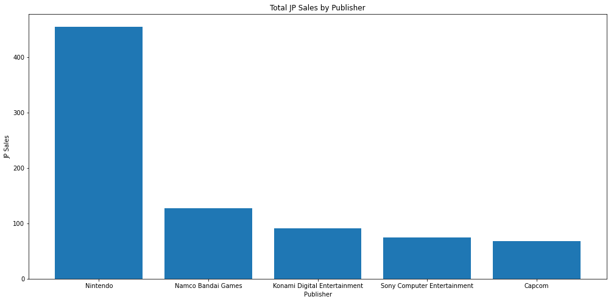

```python
plt.figure(figsize=(17, 8))
plt.bar(top5pubsjap['Publisher'], top5pubsjap['JP_Sales'])

plt.xlabel('Publisher')
plt.ylabel('JP Sales')
plt.title('Total JP Sales by Publisher')


#shows the top publishers in the region
```

```python
publisher_sales_NA = vgsales.groupby('Publisher')['NA_Sales'].sum().reset_index()

publisher_sales_NA_sorted = publisher_sales_NA.sort_values('NA_Sales', ascending=False)
```

```python
top5pubsNA = publisher_sales_NA_sorted.head(5)
top5pubsNA
```

|  | Publisher | NA_Sales |
| --- | --- | --- |
| 359 | Nintendo | 816.87 |
| 138 | Electronic Arts | 595.07 |
| 21 | Activision | 429.70 |
| 456 | Sony Computer Entertainment | 265.22 |
| 525 | Ubisoft | 253.43 |

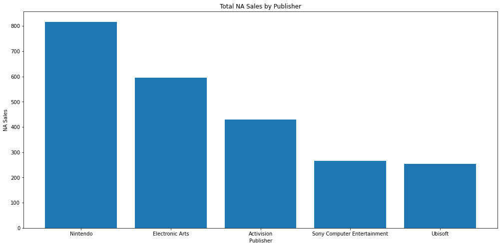

```python
plt.figure(figsize=(17, 8))
plt.bar(top5pubsNA['Publisher'], top5pubsNA['NA_Sales'])


plt.xlabel('Publisher')
plt.ylabel('NA Sales')
plt.title('Total NA Sales by Publisher')

#shows the top publishers in the region
```

```python
publisher_sales_EU = vgsales.groupby('Publisher')['EU_Sales'].sum().reset_index()

publisher_sales_EU_sorted = publisher_sales_EU.sort_values('EU_Sales', ascending=False)
```

```python
top5pubsEU = publisher_sales_EU_sorted.head(5)
top5pubsEU
```

|  | Publisher | EU_Sales |
| --- | --- | --- |
| 359 | Nintendo | 418.74 |
| 138 | Electronic Arts | 371.27 |
| 21 | Activision | 215.53 |
| 456 | Sony Computer Entertainment | 187.72 |
| 525 | Ubisoft | 163.32 |

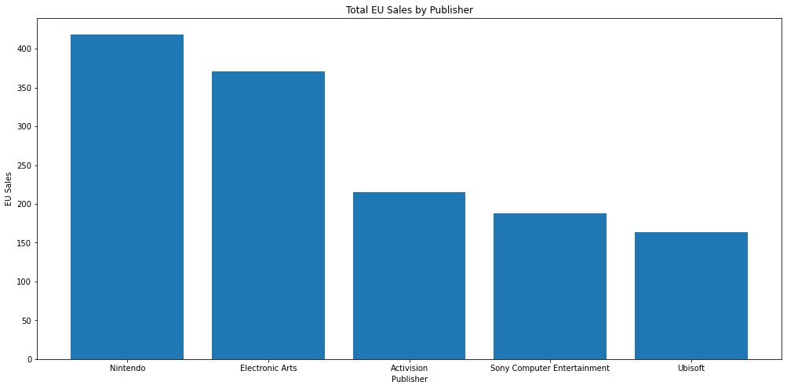

```python
plt.figure(figsize=(17, 8))
plt.bar(top5pubsEU['Publisher'], top5pubsEU['EU_Sales'])

plt.xlabel('Publisher')
plt.ylabel('EU Sales')
plt.title('Total EU Sales by Publisher')

#shows the top publishers in the region
```

```python
publisher_sales_Other = vgsales.groupby('Publisher')['Other_Sales'].sum().reset_index()

publisher_sales_Other_sorted = publisher_sales_Other.sort_values('Other_Sales', ascending=False)
```

```python
top5pubsOther = publisher_sales_Other_sorted.head(5)
top5pubsOther
```

|  | Publisher | Other_Sales |
| --- | --- | --- |
| 138 | Electronic Arts | 129.77 |
| 359 | Nintendo | 95.33 |
| 456 | Sony Computer Entertainment | 80.45 |
| 21 | Activision | 75.34 |
| 494 | Take-Two Interactive | 55.24 |

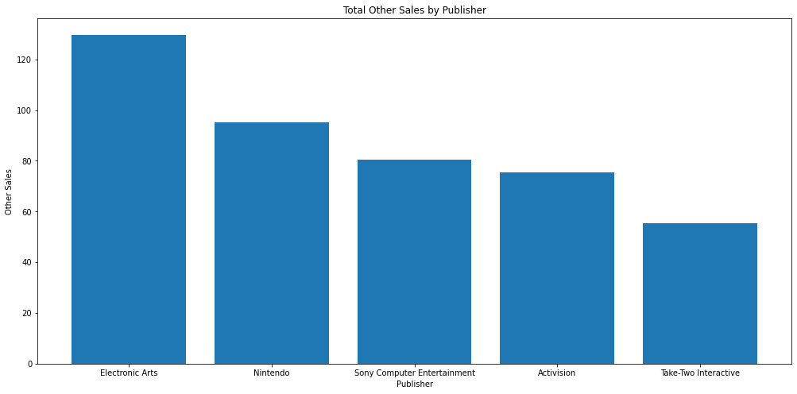

```python
plt.figure(figsize=(17, 8))
plt.bar(top5pubsOther['Publisher'], top5pubsOther['Other_Sales'])

plt.xlabel('Publisher')
plt.ylabel('Other Sales')
plt.title('Total Other Sales by Publisher')

#shows the top publishers in the region
```

```python
publisher_sales_Global = vgsales.groupby('Publisher')['Global_Sales'].sum().reset_index()

publisher_sales_Global_sorted = publisher_sales_Global.sort_values('Global_Sales', ascending=False)
```

```python
top5pubsGlobal = publisher_sales_Global_sorted.head(5)
top5pubsGlobal
```

|  | Publisher | Global_Sales |
| --- | --- | --- |
| 359 | Nintendo | 1786.56 |
| 138 | Electronic Arts | 1110.32 |
| 21 | Activision | 727.46 |
| 456 | Sony Computer Entertainment | 607.50 |
| 525 | Ubisoft | 474.72 |

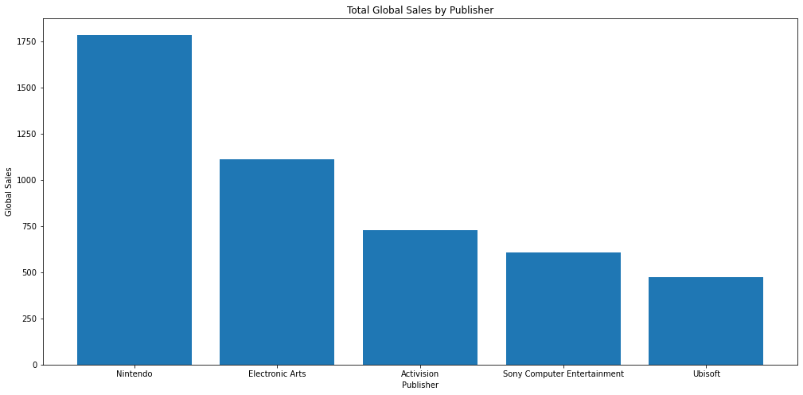

```python
plt.figure(figsize=(17, 8))
plt.bar(top5pubsGlobal['Publisher'], top5pubsGlobal['Global_Sales'])

plt.xlabel('Publisher')
plt.ylabel('Global Sales')
plt.title('Total Global Sales by Publisher')

#shows the top publishers in the world
```